```python
# GEM 530 – Project Proposal Notebook
# Group Members: Andrew Lang Wong, Gayatri Kulkarni, Sarah Kopitz
# Date: 11/25/2025
```

# **A Geospatial Terrain Assessment of Cutblocks in Central British Columbia**

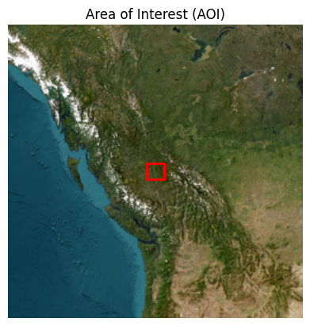

## **1. Background & Motivation**

Forested canopies play an important role in moderating rainfall by intercepting precipitation and reducing the amount that reaches the ground (Pike et al., 2010). When forests are removed this interception buffer disappears allowing more rainfall to reach the ground directly (Pike et al., 2010).

These changes align with hydrologic patterns documented by Pham et al. (2025), who found that clearcuts generate stronger and faster runoff responses during rainfall events due to the absence of canopy moderation. In their study, flooding was up to 18 times more likely in clearcut areas, partly because reduced interception contributes to higher Antecedent Moisture Conditions (Pham et al., 2025). Clearcutting therefore increases the proportion of rainfall converted to surface runoff because the forest floor and canopy no longer absorb or delay moisture inputs.

Terrain further influences how these hydrologic shifts translate into actual hazards. In the Hancock & Wlodarczyk (2025) dataset, each landslide, debris flow, debris flood, bank failure, or slope failure triggered by the 2021 atmospheric river was mapped at the exact point where the failure began. A total of 1,360 failure initiation points were recorded across southwestern BC, and about 15% occurred inside logging cutblocks (Hancock & Wlodarczyk, 2025).

Together, these studies show that canopy removal alters how rainfall is delivered to the ground, and topography determines how that water moves once it arrives. Because slope, aspect, and related terrain variables influence both hydrologic response and slope stability, summarizing the topographic conditions of historic cutblocks is an important first step in understanding where harvested areas may be more sensitive during extreme rainfall events.

**What gap or problem are we addressing?**

Despite the importance of terrain in shaping responses after harvesting. There is no simple geospatial summary of the topographic conditions where historic cutblocks in the AOI are located. While slope, aspect, elevation, and curvature exist in the underlying datasets, they have not been brought together into one integrated analysis. Our project fills this gap by creating a terrain profile of historic cutblocks. This baseline summary supports future work that may examine geohazard or hydrologic risk in relation to harvesting patterns.

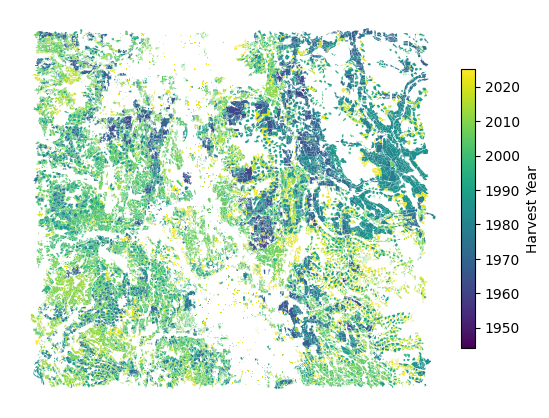

*Figure 1. Harvested areas in Central British Columbia from 1950 - 2025.*

## **2. Objectives**

**General Objective**

To summarize the terrain characteristics of harvested cutblocks in the AOI and understand how topography (slope, aspect, elevation, curvature) and hydrologic zones influence where harvesting has occurred over time.

**Specific Objectives**:

1. **Calculate terrain metrics** — slope, aspect, elevation, curvature.
2. **Characterize the terrain inside harvested cutblocks** - including average and standard deviation of slope, aspect, elevation, and curvature, and grouped slopes into broad classes
3. **Examine temporal patterns in harvested terrain** - such as whether more recent harvests occur on steeper slopes or different aspects over time.
4. **Compare terrain characteristics across hydrologic zones** - identifying which zones contain more variable harvested terrain.
5. **Assess harvesting trends within hydrologic zones** - including which zones have the most harvesting activity

## **3. Proposed Methods**

**Proposed libraries**:

- **os** - to manage project folders and file paths
- **arcpy** - to generate terrain rasters and run zonal statistics
- **geopandas** - to generate an attribute table with cutblock-specific statistics
- **matplotlib** - to visualize results in graphs and figures
- **seaborn** - to visualize results in graphs and figures

**Data sources**:

- **Cutblock / harvested areas layer** for the study area (cutblocks from BC open data).
- **DEM raster** (30m resolution).
- **AOI boundary** (polygon layer) to clip the DEM and limit the analysis area.
- **BC Hydrologic Zones** for extended analysis

**Workflow**:

- Automate a basic workflow to extract and describe spatial and temporal trends in our AOI
- Vizualize these trends using figures and graphs

```python
#STEP 1: Import libraries
import os
import arcpy
from arcpy.sa import ZonalStatisticsAsTable
from simpledbf import Dbf5
import geopandas as gpd
import pandas as pd
import matplotlib.pyplot as plt
import seaborn as sns

#Set up workspace
arcpy.CheckOutExtension("Spatial")
arcpy.env.workspace = os.chdir(r"data\scratch")
arcpy.env.overwriteOutput = True
```

```python
#STEP 2: Calculate aspect, slope, curvature from dem

dem = r"dem.tif"

#calculate slope
slope_output = arcpy.sa.Slope(
        in_raster= dem,
        output_measurement="DEGREE")
slope_output.save(r"slope.tif")

#calculate aspect
aspect_output = arcpy.sa.Aspect(
    in_raster = dem)
aspect_output.save(r"aspect.tif")

#calculate curvature
curvature_output = arcpy.sa.Curvature(
        in_raster = dem,
        z_factor = 1)
curvature_output.save(r"curvature.tif")
```

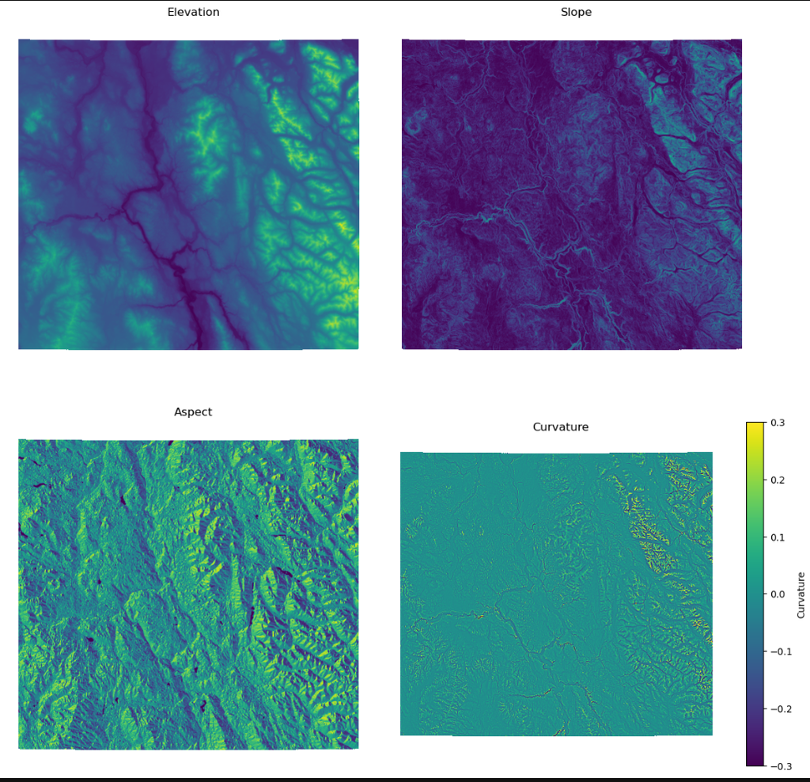

```python
#STEP 3: calculate zonal statistics by cutblock

zone_field = "BLOCK_ID"
output_folder = r"scratch\Outputs"

elev = r"dem.tif"
slope = r"slope.tif"
aspect = r"aspect.tif"
curv = r"curvature.tif"

#function for calculating mean and standard deviation using zonal statistics
def zonal_stats(raster, out_name):

    out_mean_std = fr"{output_folder}\{out_name}_mean_std.dbf"
    ZonalStatisticsAsTable(
        in_zone_data=cutblocks,
        zone_field=zone_field,
        in_value_raster=raster,
        out_table=out_mean_std,
        statistics_type="MEAN_STD",
        ignore_nodata="DATA"
    )

# Run for all four rasters
zonal_stats(elev,  "zstats_elevation")
zonal_stats(slope, "zstats_slope")
zonal_stats(aspect, "zstats_aspect")
zonal_stats(curv,  "zstats_curvature")
```

```python
#STEP 5: clean up zonal statistics tables and rename fields for better merging
folder = output_folder

# list of (filename, layername) pairs
tables = [
    ("zstats_elevation_mean_std.dbf", "elev"),
    ("zstats_slope_mean_std.dbf",     "slope"),
    ("zstats_aspect_mean_std.dbf",    "aspect"),
    ("zstats_curvature_mean_std.dbf", "curv")]

cleaned = {}  # store cleaned dfs

for filename, layer in tables:
    path = os.path.join(folder, filename)

    # Load DBF into a pandas DataFrame
    dbf = Dbf5(path)
    df = dbf.to_dataframe()

    # Drop unnecessary columns
    df = df.drop(columns=["OID", "COUNT", "AREA"], errors="ignore")

    # Rename MEAN and STD to layer-specific names
    df = df.rename(columns={
        "MEAN": f"{layer}_mean",
        "STD":  f"{layer}_std",
        "HARVEST__!": "HARVEST_YEAR"})

    cleaned[layer] = df

# Merge all cleaned dfs on BLOCK_ID
master = cleaned["elev"] \
            .merge(cleaned["slope"], on="BLOCK_ID") \
            .merge(cleaned["aspect"], on="BLOCK_ID") \
            .merge(cleaned["curv"], on="BLOCK_ID")

#STEP 6:
cutblocks_gdf = gpd.read_file(cutblocks)

# Merge zonal stats master table
df = cutblocks_gdf.merge(master, on="BLOCK_ID", how="left")

#group by Harvest year 1
df.groupby("HARVEST_YEAR").agg({
    "elev_mean": ["mean", "std"],
    "slope_mean": ["mean", "std"],
    "aspect_mean": "mean",
    "curv_mean": "mean"})
```

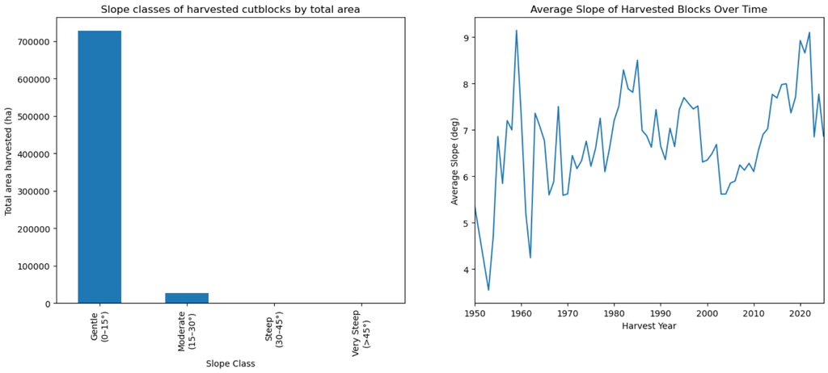

```python
#create slope class bins based on BC slope classification
bins = [0, 15, 30, 45, 90]
labels = ["Gentle (0–15°)", "Moderate (15–30°)", "Steep (30–45°)", "Very Steep (>45°)"]

#create a slope class dataframe using bins and labels described above
df["slope_class"] = pd.cut(df["slope_MEAN"], bins=bins, labels=labels, right=False)

#group by slope class and total area harvested
area_by_class = df.groupby("slope_class")["AREA_HA"].sum()

#plot graphs side by side
fig, axes = plt.subplots(1, 2, figsize=(16, 6))

#plot slope class by total area harvested
area_by_class.plot(kind="bar", ax=axes[0])
axes[0].set_ylabel("Total area harvested (ha)")
axes[0].set_xlabel("Slope Class")
axes[0].set_title("Slope classes of harvested cutblocks by total area")

#plot average slope of harvested blocks over time
(df.groupby("HARVEST_YEAR")["slope_MEAN"].mean()
   .plot(kind="line", ax=axes[1]))

axes[1].set_ylabel("Average Slope (deg)")
axes[1].set_xlabel("Harvest Year")
axes[1].set_title("Average Slope of Harvested Blocks Over Time")
axes[1].set_xlim([1950, 2025])
plt.show()
```

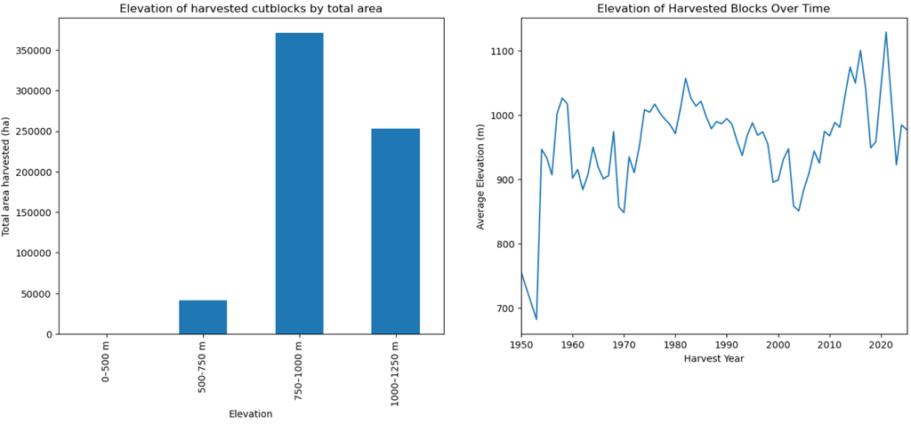

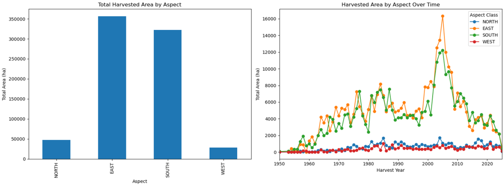

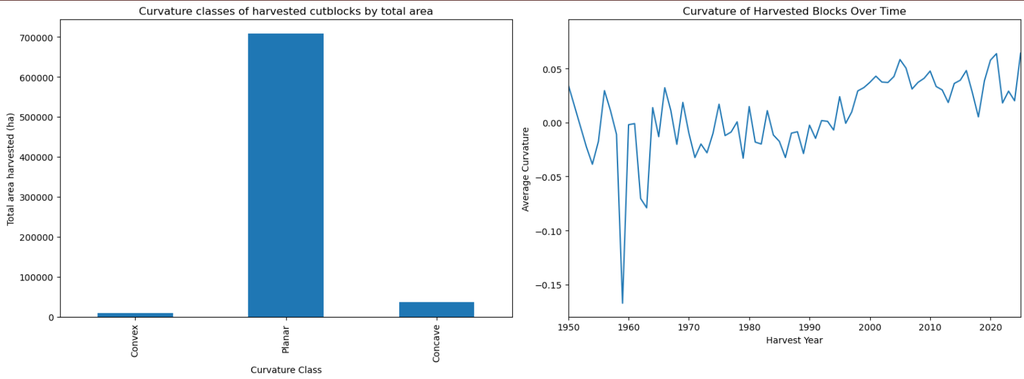

## **Explore the Hydrologic Zones & Harvesting Interaction to understand flooding and other geohazard implications**

- Obtaining additional data sources:
  - BC hydrologic zone: The BC Hydrologic Zones represent regions of similar climate and terrain resulting in somewhat homogeneous hydrology characteristics.
- High level workflow process followed:
  - Downloaded the BC Hydrologic Zones data from the BC Data Catalogue
  - Clipped it to our Area of Interest
  - Performed spatial join on the clipped hydrologic zone data & cutblocks
  - Merged this with our master dataset containing terrain metrics
  - Finally, we visualized the results through a series of plots

```python
#Step 1 - Download the BC Hydrologic Zones shapefile from the BC Data Catalogue.
#Step 2 -Clip these dataset to our Area of Interest
arcpy.env.overwriteOutput = True
#define input and clip feature
input_feature = ["BC_Hydrologic_Zones.shp", "Flood_Frequency_Analysis_Watershed.shp", "FloodFreqStation.shp"]
clip_feature = "aoi_polygon2.shp"
#for loop that uses arcpy.analysis.CLip on each of the input features, and renames the output feature
for fc in input_feature:
    base_name = os.path.splitext(os.path.basename(fc))[0]  # Remove .shp
    output_feature = os.path.join(output_folder, f"clipped_{base_name}.shp")
    arcpy.analysis.Clip(fc, clip_feature, output_feature)
    print(f"Created: {output_feature}")

#Step 3 - Perform spatial join on the clipped hydrologic zone data & cutblocks
import geopandas as gpd

# Read hydrologic zones
zones = gpd.read_file(
    r"C:\Users\gayatrik.stu\OneDrive - UBC\Documents\MGEM\GEM 530\Proposal\data\cutblocks_topo\scratch\Outputs\clipped_BC_Hydrologic_Zones.shp"
)

# Spatial join: cutblocks & hydrologic zones
cutblocks_in_zones = gpd.sjoin(
    cutblocks,
    zones,
    how="left",
    predicate="intersects"
)

#STEP 4 - Merge the above dataset with the master dataframe including all metrics such as slope, aspect and curvature
cutblocks_zones_metrics = cutblocks_in_zones.merge(df, on="BLOCK_ID", how="left")
# Display all column names
print(cutblocks_zones_metrics.columns.tolist())
```

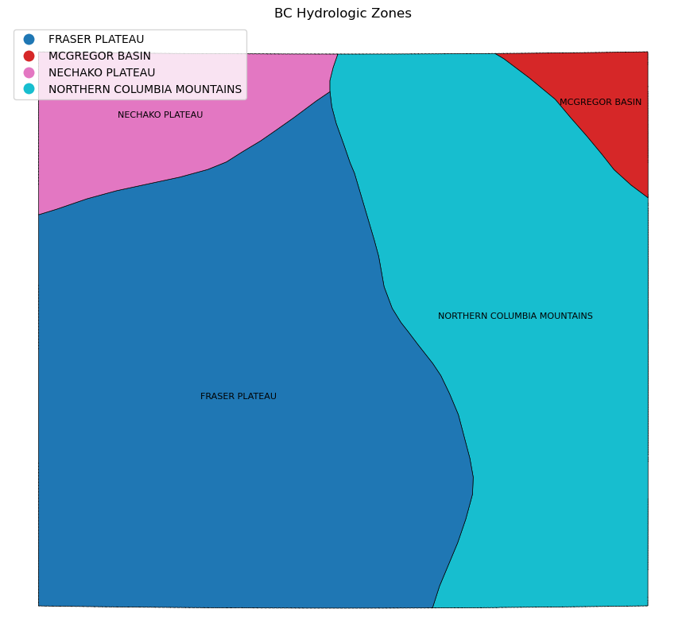

```python
#Plot 1 — Mean Slope by Hydrologic Zone
import matplotlib.pyplot as plt
import seaborn as sns

# Shared color palette
palette = sns.color_palette("tab10")

# ------------------ Plot 1 ------------------
plt.figure(figsize=(10, 6))

sns.barplot(data=df,x="HYDZN_NAME",y="slope_mean",errorbar="sd",palette=palette)
plt.title("Mean Slope by Hydrologic Zone", fontsize=14)
plt.ylabel("Slope (degrees)")
plt.xlabel("Hydrologic Zone")
plt.xticks(rotation=30)

plt.tight_layout()
plt.show()

#Plot 2 — Mean Curvature by Hydrologic Zone
# ------------------ Plot 2 ------------------
plt.figure(figsize=(10, 6))

sns.barplot(data=df,x="HYDZN_NAME",y="curv_mean",errorbar="sd",palette=palette)

plt.title("Mean Curvature by Hydrologic Zone", fontsize=14)
plt.ylabel("Curvature")
plt.xlabel("Hydrologic Zone")
plt.xticks(rotation=30)
plt.tight_layout()
plt.show()
```

**For Mean Slope by Hydrologic Zone:**

- Northern Columbia Mountains and McGregor Basin have the steepest terrain
- Nechako Plateau is the flattest zone
- High variability in slope within zones

**For Curvature by Hydrologic Zone:**

- Mean curvature is near zero across all zones
- McGregor Basin has the least curvature variability

**Implications**

Zones with steep slopes, like Northern Columbia Mountains and McGregor Basin, face elevated risks of rapid runoff, localized water pooling, and erosion, amplifying both flooding and slope failure hazards.

[figure not shown]

[figure not shown]

**Harvested Area Over Time by Hydrologic Zone:**

- Fraser Plateau experienced the highest harvesting intensity with over 20k ha in 2005.
- There seems to be a decrease in harvesting activity in Northern Columbia Mountains from 1980's until the present
- Nechako Plateau and McGregor Basin remained consistently low, with harvested areas rarely exceeding 5,000 ha/year.

**Implications**

Extensive harvesting in the Fraser Plateau and Northern Columbia Mountains reduces forest cover, diminishing interception and infiltration, which can elevate peak flows, intensify flooding, and destabilize slopes, increasing landslide risk.

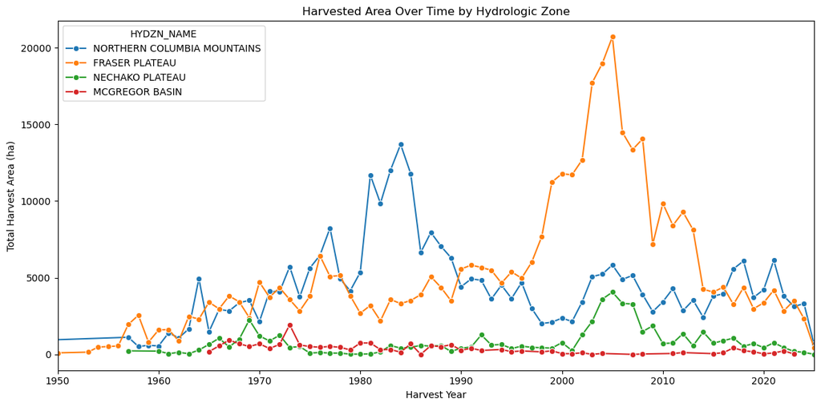

**Top 10 Steepest Cutblocks per Hydrologic Zone:**

**Top 10 Largest Cutblocks per Hydrologic Zone:**

- Both Fraser Plateau and Northern Columbia has the largest and most variable cutblocks, some over 900 ha, indicating intensive harvesting.
- McGregor Basin & Nechako Plateau has smaller cutblocks (generally < 500 ha), reflecting less intensive harvesting.

**Implications**

Large cutblocks (>800 ha) in steep terrain (>30°), especially in the Northern Columbia Mountains and Fraser Plateau, can greatly increase landslide risk by reducing canopy interception, leading to higher runoff, peak flows, and slope instability after harvesting.

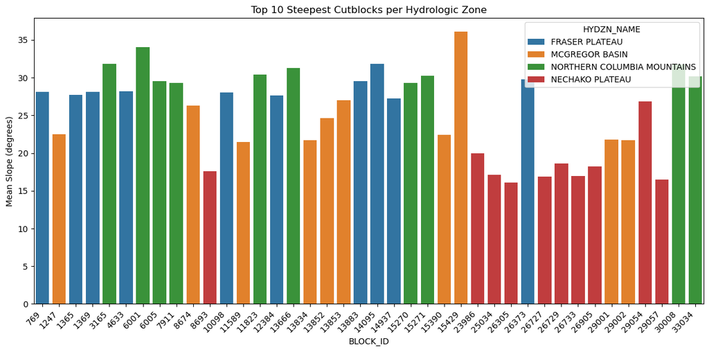

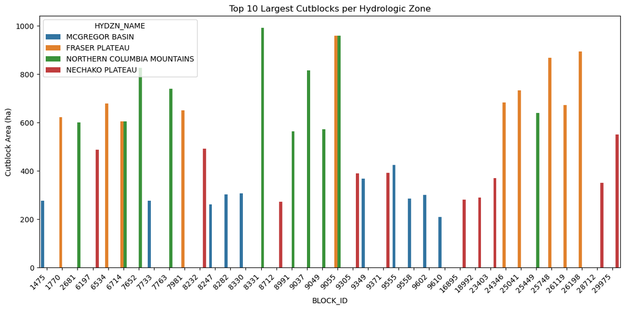

## **4. Future Scope of Work & Expected Outcomes**

Using additional available data sources such as BC Regional Flood Frequency Analysis Hydrostation and BC Regional Flood Frequency Analysis Watershed shapefiles, we can potentially expand the scope of the analysis to achieve:

- Develop spatial models combining terrain metrics, watershed, and harvest intensity to predict flooding.
- Validate terrain-based hazard predictions using observed hydrometric data for runoff and erosion models.
- Integrate watershed boundaries with cutblock and hydrologic zone data to assess cumulative harvesting impacts on watershed-scale hydrology

**Expected Outcomes**

- Risk maps for flooding and landslides integrating slope, curvature, watershed connectivity, and harvest patterns.
- Flood frequency analsyis and prediction
- Baseline for long-term monitoring for proactive management and risk mitigation

## **5. Challenges & Limitations**

- **Partial Zone Coverage:** Because the hydrologic zones extend beyond our defined area of interest, our analysis represents only a subset of these zones. As a result, the findings may not fully reflect conditions across the entire zone scale.
- **Causality vs. correlation:** Harvesting and hydrologic responses can co‑vary with other factors such as wildfires, beetle outbreaks, or unusual climate years, which can make it hard to isolate harvesting as the true cause.
- **Lags & changing baselines:** Hydrologic and slope responses often appear months–years after harvest, while climate change shifts baseline conditions over time.

## **6. References (Optional)**

Hancock, C., & Wlodarczyk, K. (2025). The role of wildfires and forest harvesting on geohazards and channel instability during the November 2021 atmospheric river in southwestern British Columbia, Canada. Earth Surface Processes and Landforms, 50(1), e6065. https://doi.org/10.1002/esp.6065

Pham, H. C., Alila, Y., & Caldwell, P. V. (2025). Stochastic framework reveals the controls of forest treatment – peakflow causal relations in rain environment. Journal of Hydrology, 661, 133704. https://doi.org/10.1016/j.jhydrol.2025.133704

Pike, R.G., T.E. Redding, R.D. Moore, R.D. Winker and K.D. Bladon (editors). 2010. Compendium of forest hydrology and geomorphology in British Columbia. B.C. Min. For. Range, For. Sci. Prog., Victoria, B.C. and FORREX Forum for Research and Extension in Natural Resources, Kamloops, B.C. Land Manag. Handb. 66. www.for.gov.bc.ca/hfd/pubs/Docs/Lmh/Lmh66.htm